# 逆累積分布関数について

UPDATE: 2023-12-09 16:41:07

# はじめに

このノートは、逆累積分布関数についてについて簡単にまとめているもの。様々なパラメタを持つ正規分布に対して、常に上側5%となる$x$の値を知りたい場合に、少し混乱したので、忘れないうちにまとめておく。逆累積分布関数は分位点関数とも呼ばれる。

## 逆累積分布関数(Inverse cumulative distribution function; ICDF)

まずは累積分布関数(CDF)の定義をおさらいしておく。累積分布関数は$X$が$x$以下の値となる確率$p$を表す関数。

$$F_{X}(x) = Pr(X \le x) = p$$
Rの標準正規分布の累積分布関数であれば`pnorm(q)`が対応する。つまり、入力は分位数であり、下記の例では$x=1.96$以下の値となる確率$p$を返す。

```r
pnorm(q = 1.96, 0, 1, lower.tail = TRUE)
```

```
## [1] 0.9750021
```

この関数の逆関数なので、逆累積分布関数は、確率$p$となる$x$の値を返す関数。

$$F^{-1}_{X}(p) = Q(p)$$

Rの標準正規分布の累積分布関数であれば`qnorm(p)`が対応する。つまり、入力は確率であり、下記の例では$p=0.975$となる分位数$q$を返す。

```r
qnorm(p = 0.9750021, 0, 1, lower.tail = TRUE)
```

```
## [1] 1.96
```

関係性をまとめると下記の図の通り。

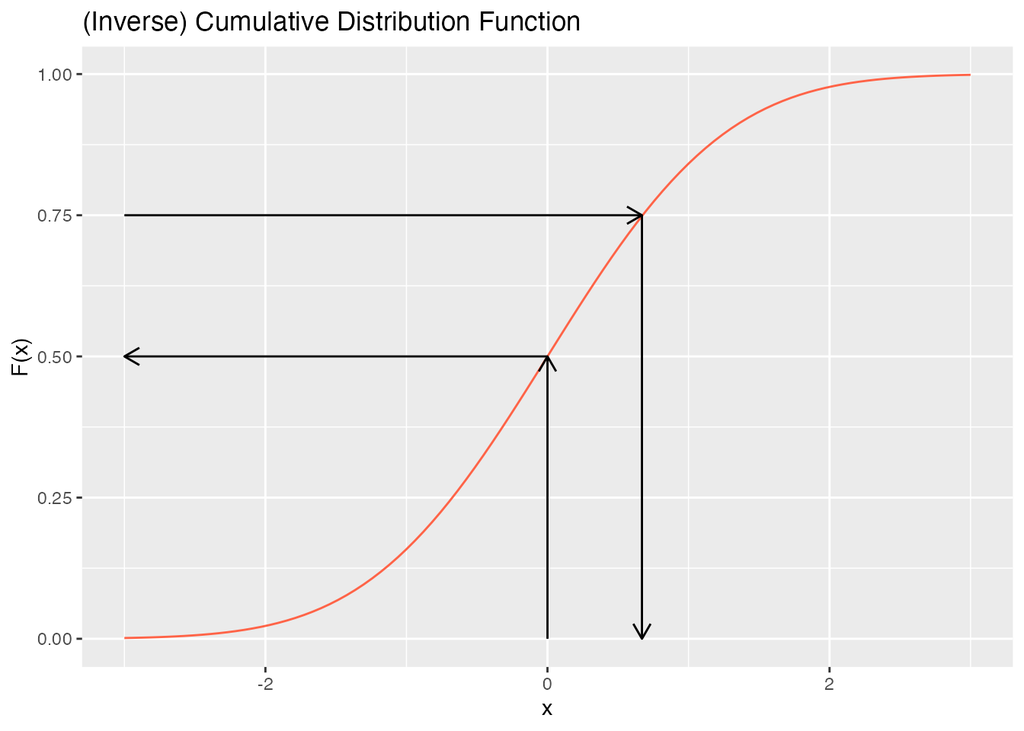

```r
library(ggplot2)
mu <- 0
sd <- 1
x <- seq(-3, 3, length = 100)
y <- pnorm(x, mean = mu, sd = sd)

# pnorm, qnormを使って計算するほうが望ましい
arrow_data <- data.frame(
  x1 = c(0.0, 0.0,-3.00, 0.67),
  x2 = c(0.0,-3.0, 0.67, 0.67),
  y1 = c(0.0, 0.5, 0.75, 0.75),
  y2 = c(0.5, 0.5, 0.75, 0.00)
)

ggplot() +
  geom_line(aes(x, y), col = "tomato") +
  geom_segment(data = arrow_data,
               aes(x = x1, y = y1, xend = x2, yend = y2),
               arrow = arrow(length = unit(.3, 'cm'))
               ) +
  labs(title = "(Inverse) Cumulative Distribution Function",
       x = "x",
       y = "F(x)")
```

本題に移るが、標準正規分布ではなく、様々なパラメタを持つ正規分布に対して、常に上側5%となる$x$の値を知りたいという場合はどうすればよいのか。これは素直にRの力をお借りすれば、`pnorm, qnorm`のパラメタを調整すればよい。

ここでは$\mu=100, sd=5$のときの正規分布を対象に、$x=100$以下の値となる確率$p=0.5$、$p=0.95$となる分位数$q=108.2243$の関係性を可視化している。

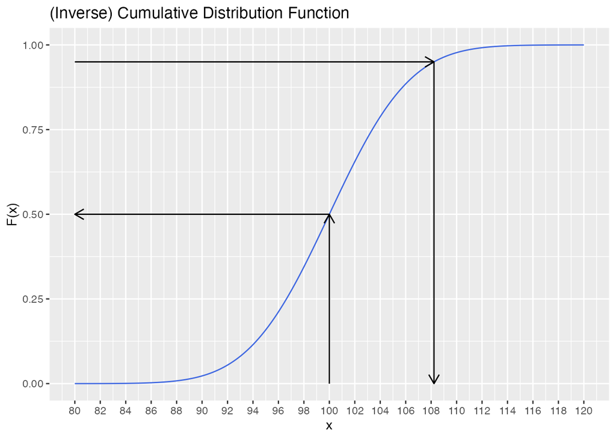

```r
mu <- 100
sd <- 5
x <- seq(80, 120, length = 1000)
y <- pnorm(x, mean = mu, sd = sd)

p <- 0.95
# 上側の場合はlower.tail = FALSEを設定する
# pnorm(x, mu, sd, lower.tail = FALSE) -> 0.05 を返す
p1 <- pnorm(mu, mean = mu, sd = sd)
p2 <- qnorm(p, mean = mu, sd = sd)
xmin <- min(x)
arrow_data <- data.frame(
  x1 = c(mu, mu  , xmin, p2),
  y1 = c( 0, p1  , p   , p ),
  x2 = c(mu, xmin, p2  , p2),
  y2 = c(p1, p1  , p   , 0 )
)

ggplot() +
  geom_line(aes(x, y), col = "royalblue") +
  geom_segment(data = arrow_data,
               aes(x = x1, y = y1, xend = x2, yend = y2),
               arrow = arrow(length = unit(.3, 'cm'))
  ) +
  scale_x_continuous(breaks = seq(80,120,2)) +
  labs(title = "(Inverse) Cumulative Distribution Function",
       x = "x",
       y = "F(x)")
```

Rにこのような便利な引数がなければどうすればよいのか。このようなときは、標準化を利用すれば良い。ここでは分位数を最終的に求めたいので、$x$を$q$で表記している。

$$z = \frac{q-\mu}{\sigma}$$

この式をzについて整理すれば、標準化前の値は、平均と標準偏差が分かれば計算することができる。

$$q = \mu + \sigma * z$$

$\mu=100, sd=5$のときの正規分布を対象に、確率$p$が95%以下となる$x$の値を知りたいとする。標準正規分布の世界では、95%となるときの$z$の値は1.64である。教科書の末尾の数表をみればわかる。

```r
mu <- 100
sd <- 5
z <- qnorm(0.95, 0, 1)
list(mu = mu, sd = sd, z = z)
```

```
## $mu
## [1] 100
##
## $sd
## [1] 5
##
## $z
## [1] 1.644854
```

これらの数値を利用して、$\mu=100, sd=5$のときの正規分布の世界の値を計算すると、$q=108.2243$が得られる

```r
# 逆正規分布関数を用いて位置 q を計算
# mu + sd * qnorm(0.95, 0, 1)
q <- mu + sd * z
q
```

```
## [1] 108.2243
```

つまり、下記の通り、引数を使わずとも、標準化を利用すれば、様々なパラメタを持つ正規分布であっても、確率$p$が95%以下となる$x$の値を計算できる。

```r
qnorm(p, mean = mu, sd = sd)
```

```
## [1] 108.2243
```

## 参考文献

- [分位関数](https://en.wikipedia.org/wiki/Quantile_function)